# HHS Exploration

RW Hass

2024-03-05

### Data description

This is data from the 2018 Southeastern PA Household Health Survey (SEPA-HHS). More details are available in Week 9’s module under HHS Data and Materials

#### Cleaning

The following script imports and cleans the data housed in an SPSS .sav file. To re-construct the data, set your working directory to the one housing the SPSS file and run the script

```r
library(foreign)

HHS <- read.spss("HHS18AR_2.sav", use.value.labels = TRUE, to.data.frame = TRUE, max.value.labels = 98, add.undeclared.levels = "no")


keep <- c("COUNTY","ZIPCODE","ZIPREGION","SEX01","RESPAGE_4CAT","TOTKIDS","NUMADULT2",
          "HLTHA5","DOCVST3","HOSPERA2","INSUREDA2","BMI","XERCISE_2CAT","FRUITS")

HHS_clean <- HHS[, keep]

HHS_clean <- na.omit(HHS_clean)

for (i in 1:nrow(HHS_clean)){
  if (HHS_clean$COUNTY[i] == "Philadelphia"){
    HHS_clean$COUNTY_2CAT[i] <- "Philadelphia"
  } else {
    HHS_clean$COUNTY_2CAT[i] <- "Not Philadelphia"
  }
}
```

I decided to use only these variables based just on heuristics. If you would like to include more, you are free to do so by simply adding the column names to the `keep` object. Be aware, that depending on the variable, there may be so many `NA` values that the `na.omit` command will exclude nearly everyone.

#### Levels

The most natural clustering or random factor is zip code. However, this will make things difficult later as there are several zip codes with only 1 respondent. Here’s the list:

```r
tab <- table(HHS_clean$ZIPCODE)
tab
```

```
##
## 17527 18036 18041 18054 18055 18073 18074 18076 18077 18081 18901 18902 18913
##     1     5     7     4     1    16     7     5     6     2    45    24     1
## 18914 18915 18917 18920 18925 18927 18929 18930 18932 18933 18936 18938 18940
##    18     3     5     3     8     1    13     8     1     1     1    35    26
## 18942 18944 18947 18951 18954 18960 18964 18966 18969 18972 18974 18976 18977
##     7    31    11    54    16    30    22    59    25     4    80    31     9
## 19001 19002 19003 19004 19006 19007 19008 19010 19012 19013 19014 19015 19018
##    29    61    28    23    32    29    43    32    11    39    27    21    42
## 19020 19021 19022 19023 19025 19026 19027 19029 19030 19031 19032 19033 19034
##    68    12     3    32     8    59    44     3    17    12    11    12     7
## 19035 19036 19038 19040 19041 19043 19044 19046 19047 19050 19053 19054 19055
##     6    22    56    27    19     5    19    34    69    52    38    20    14
## 19056 19057 19060 19061 19063 19064 19066 19067 19070 19072 19073 19074 19075
##    24    30    23    36    86    42    13    96    13    17    44    10    11
```

[output cut: 18 more lines]

```r
length(tab) # number of different zip codes
```

```
## [1] 206
```

Fortunately, there is a constructed variable called `ZIPREGION` which will also work as a random factor here’s the breakdown:

```r
tab2 <- table(HHS_clean$ZIPREGION)
tab2
```

```
##
##              Center City              South Phila                 SW Phila
##                      118                      318                      209
##               West Phila            Lower N Phila            Upper N Phila
##                      301                      159                      174
##          Brides Ken Rich          Roxbor Manayunk          German Ch. Hill
##                      127                       73                      244
##           Olney Oak Lane                 Lower NE                 Upper NE
##                      287                      351                      302
##              Bucks North            Bucks Central      Bucks Central-South
##                      175                      183                      289
##              Bucks South        Chester Northeast  Chester North-Northwest
##                      321                      216                      188
##            Chester South     Chester Central-East           Delaware South
##                      196                      302                      146
##    Delaware Central-East       Delaware Northeast           Delaware North
##                      204                      251                      226
##            Delaware West          Montgomery East     Montgomery Southeast
##                      139                      401                      124
## Montgomery Central-South     Montgomery Northeast         Montgomery North
##                      267                      201                       74
##          Montgomery West
##                      122
```

```r
length(tab2) # number of different zip code regions
```

```
## [1] 31
```

The most natural level-2 predictor is County, but to make it simpler, I set up a 2-category predictor where a respondent is either a resident of Philadelphia or not.

Here’s the summary of that category

```r
summary(as.factor(HHS_clean$COUNTY_2CAT))
```

```
## Not Philadelphia     Philadelphia
##             4064             2624
```

### The outcome: BMI

BMI was chosen as the outcome because it is numeric and somewhat normally distributed. However, following week 9, you may use multilevel logistic regression with binary outcomes.

Note that the BMI distribution is a bit skewed overall:

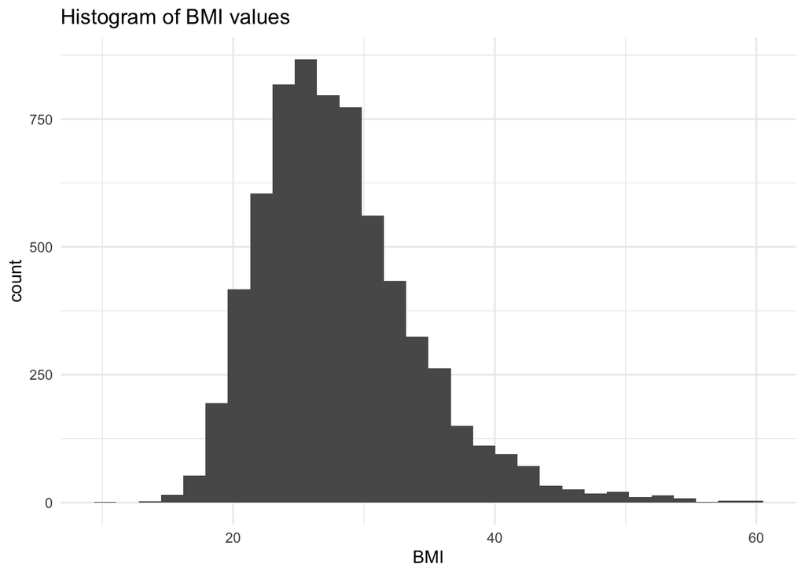

```r
require(ggplot2)
ggplot(HHS_clean, aes(BMI)) +
  geom_histogram() +
  theme_minimal() +
  labs(title = "Histogram of BMI values")
```

We can use the logarithm if we think that will help

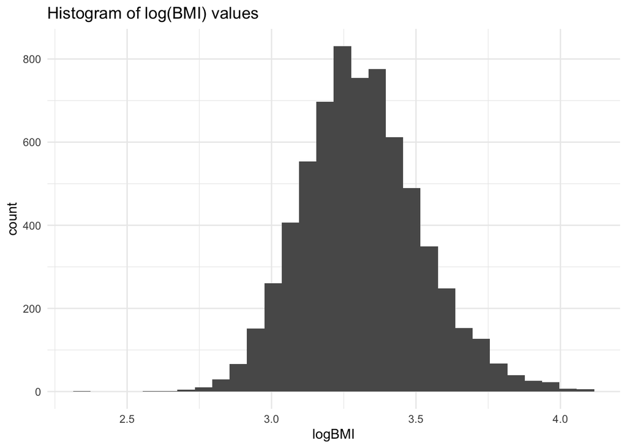

```r
HHS_clean$logBMI <- log(HHS_clean$BMI)


ggplot(HHS_clean, aes(logBMI)) +
  geom_histogram() +
  theme_minimal() +
  labs(title = "Histogram of log(BMI) values")
```

One of the issues we might have with $\log(BMI)$ is that our variance components will be very small later. Here’s what we can do:

1. Build a model using the un-transformed (raw) BMI values as the outcome and check the diagnostic plots (especially at level 1)
2. Compare these plots to one with the log-transformed data

If the assumptions are violated much more by #1, go with #2, knowing that interpretation is a bit hampered, and that variance components will be quite small

#### Variance components

To illustrate the small variance components, here’s the raw unconstrained model estimates:

```r
require(lme4)
rawmod <- lmer(BMI ~ (1|ZIPREGION), data = HHS_clean)
summary(rawmod)
```

```
## Linear mixed model fit by REML ['lmerMod']
## Formula: BMI ~ (1 | ZIPREGION)
##    Data: HHS_clean
##
## REML criterion at convergence: 43084.6
##
## Scaled residuals:
##     Min      1Q  Median      3Q     Max
## -2.7606 -0.6955 -0.1558  0.5172  5.4262
##
## Random effects:
##  Groups    Name        Variance Std.Dev.
##  ZIPREGION (Intercept)  1.004   1.002
##  Residual              36.431   6.036
## Number of obs: 6688, groups:  ZIPREGION, 31
##
## Fixed effects:
##             Estimate Std. Error t value
## (Intercept)  28.0138     0.1966   142.5
```

And the log-transformed BMI model

```r
logmod <- lmer(logBMI ~ (1|ZIPREGION), data = HHS_clean)
summary(logmod)
```

```
## Linear mixed model fit by REML ['lmerMod']
## Formula: logBMI ~ (1 | ZIPREGION)
##    Data: HHS_clean
##
## REML criterion at convergence: -2175.3
##
## Scaled residuals:
##     Min      1Q  Median      3Q     Max
## -4.5334 -0.6827 -0.0609  0.6192  3.9949
##
## Random effects:
##  Groups    Name        Variance Std.Dev.
##  ZIPREGION (Intercept) 0.00118  0.03436
##  Residual              0.04188  0.20464
## Number of obs: 6688, groups:  ZIPREGION, 31
##
## Fixed effects:
##             Estimate Std. Error t value
## (Intercept)  3.31081    0.00673     492
```

Incidentally, the ICCs are nearly identical, and quite small. This suggests that variation in BMI is mostly at the individual level. So we might not be gaining much by modeling ZIPREGION as random, but we can still profit from the ability to test the effect of living in Philadelphia on BMI using the clustering.

Below is a function that computes ICCs from unconstrained lmer models.

```r
# function to compute ICCs from unconstrained lmer models
ICClmer <- function(formula = NULL, data = NULL, model = NULL){
  if (is.null(formula)){
    x <- data.frame(VarCorr(model))
    x$vcov[1]/(x$vcov[1]+x$vcov[2])
  } else{
    model <- lmer(formula, data)
    x <- data.frame(VarCorr(model))
    x$vcov[1]/(x$vcov[1]+x$vcov[2])
  }
}

ICClmer(model = rawmod)
```

```
## [1] 0.02682736
```

```r
ICClmer(model = logmod)
```

```
## [1] 0.02741321
```

### Exploring predictors

Our predictors are all over the place as far as the scale of measurement. A quick way to see information on all variables is to use the summary command on the dataframe:

```r
summary(HHS_clean)
```

```
##              COUNTY        ZIPCODE                     ZIPREGION
##  Philadelphia   :2624   Min.   :17527   Montgomery East     : 401
##  Montgomery     :1205   1st Qu.:19053   Lower NE            : 351
##  Delaware       : 982   Median :19124   Bucks South         : 321
##  Bucks          : 973   Mean   :19142   South Phila         : 318
##  Chester        : 904   3rd Qu.:19151   Upper NE            : 302
##  Other PA county:   0   Max.   :19525   Chester Central-East: 302
##  (Other)        :   0                   (Other)             :4693
##     SEX01      RESPAGE_4CAT    TOTKIDS          NUMADULT2
##  Male  :2738   18-34: 577   Min.   : 0.0000   Min.   : 1.000
##  Female:3950   35-49:1027   1st Qu.: 0.0000   1st Qu.: 1.000
##                50-64:2365   Median : 0.0000   Median : 2.000
##                65+  :2719   Mean   : 0.4693   Mean   : 1.988
##                             3rd Qu.: 0.0000   3rd Qu.: 2.000
##                             Max.   :19.0000   Max.   :15.000
##
##         HLTHA5           DOCVST3          HOSPERA2    INSUREDA2
##  Excellent :1371   0 visits  : 603   0 visits :4906   Yes:6276
##  Very Good :2059   1-2 visits:2843   1+ visits:1782   No : 412
##  Good      :1915   3+ visits :3242
##  Fair      : 975
##  Poor      : 368
##  Don't Know:   0
##  Refused   :   0
##       BMI                XERCISE_2CAT      FRUITS       COUNTY_2CAT
##  Min.   :10.48   Less than 3/wk:2942   Min.   : 0.000   Length:6688
##  1st Qu.:23.77   3+ days per wk:3746   1st Qu.: 1.000   Class :character
##  Median :27.18                         Median : 2.000   Mode  :character
##  Mean   :28.06                         Mean   : 2.619
##  3rd Qu.:31.24                         3rd Qu.: 3.000
##  Max.   :59.90                         Max.   :11.000
##
##      logBMI
##  Min.   :2.350
##  1st Qu.:3.169
##  Median :3.302
##  Mean   :3.312
##  3rd Qu.:3.442
##  Max.   :4.093
##
```

Many of the predictors are categorical, so we can use boxplots to visualize relationships.

For example, let’s look at the distribution of BMI with and without insurance. We’ll use the un-transformed BMI

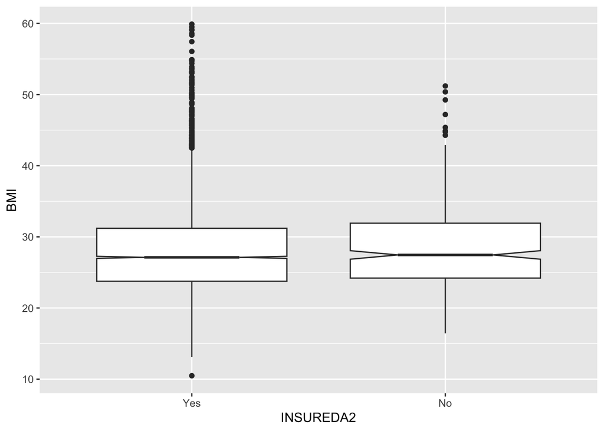

```r
ggplot(HHS_clean, aes(x = INSUREDA2, y = BMI)) +
  geom_boxplot(notch = T)
```

How about Age?

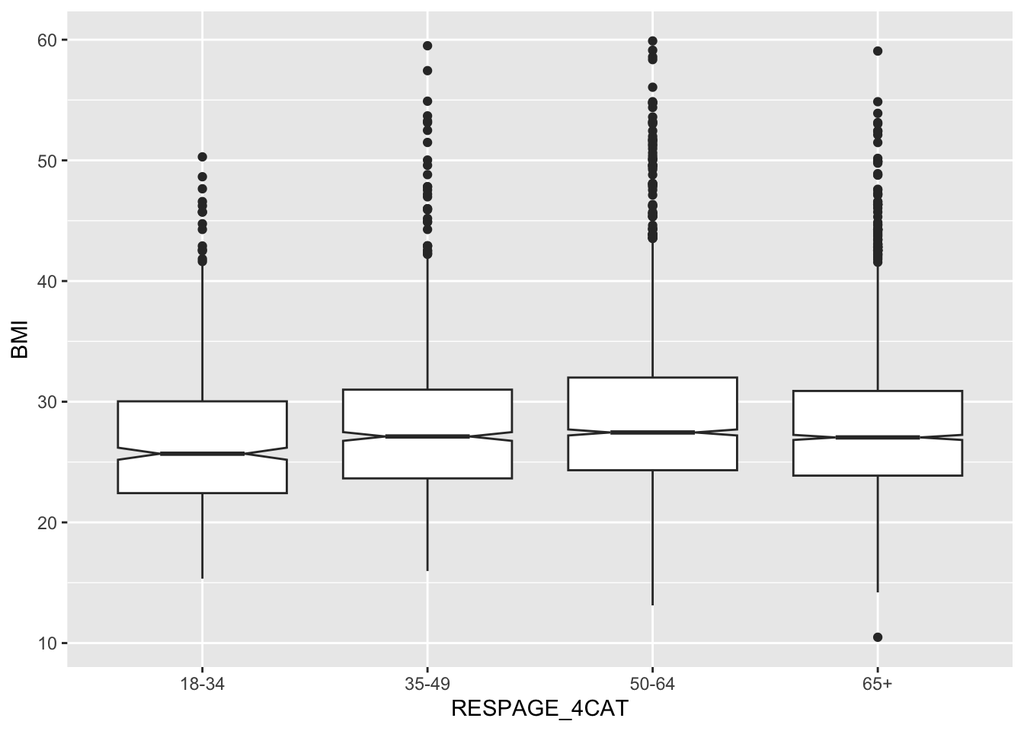

```r
ggplot(HHS_clean, aes(x = RESPAGE_4CAT, y = BMI)) +
  geom_boxplot(notch = T)
```

Or reported Health?

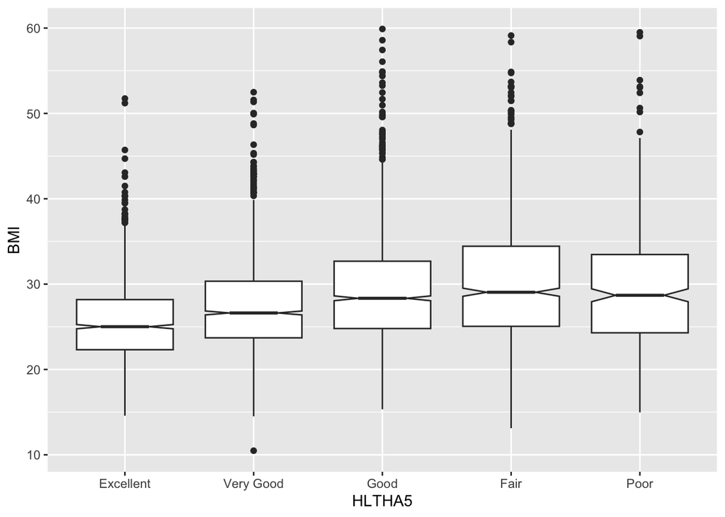

```r
ggplot(HHS_clean, aes(x = HLTHA5, y = BMI)) +
  geom_boxplot(notch = T)
```

How about with $\log(BMI)$

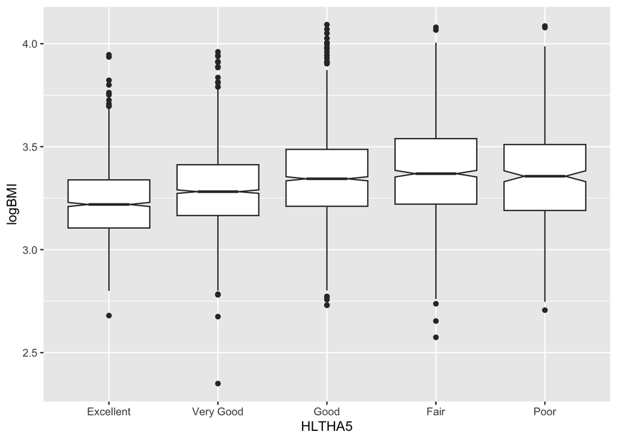

```r
ggplot(HHS_clean, aes(x = HLTHA5, y = logBMI)) +
  geom_boxplot(notch = T)
```

## Logistic Regression

Here’s an unconditional and conditional model for predicting smoking status

```r
summary(HHS$SMOKE2)
```

```
##  Yes   No NA's
##  979 6450   72
```

```r
smoke.mod <- glmer(SMOKE2 ~ (1|ZIPCODE), data = HHS, family = binomial)
summary(smoke.mod)
```

```
## Generalized linear mixed model fit by maximum likelihood (Laplace
##   Approximation) [glmerMod]
##  Family: binomial  ( logit )
## Formula: SMOKE2 ~ (1 | ZIPCODE)
##    Data: HHS
##
##      AIC      BIC   logLik deviance df.resid
##   5668.0   5681.8  -2832.0   5664.0     7357
##
## Scaled residuals:
##     Min      1Q  Median      3Q     Max
## -4.3148  0.2975  0.3520  0.4046  0.6500
##
## Random effects:
##  Groups  Name        Variance Std.Dev.
##  ZIPCODE (Intercept) 0.2802   0.5293
## Number of obs: 7359, groups:  ZIPCODE, 243
##
## Fixed effects:
##             Estimate Std. Error z value Pr(>|z|)
## (Intercept)   2.0187     0.0589   34.27   <2e-16 ***
## ---
## Signif. codes:  0 '***' 0.001 '**' 0.01 '*' 0.05 '.' 0.1 ' ' 1
```

```r
smoke.mod2 <- glmer(SMOKE2 ~ XERCISE_2CAT + BMI + (1|ZIPCODE), data = HHS, family = binomial)

summary(smoke.mod2)
```

```
## Generalized linear mixed model fit by maximum likelihood (Laplace
##   Approximation) [glmerMod]
##  Family: binomial  ( logit )
## Formula: SMOKE2 ~ XERCISE_2CAT + BMI + (1 | ZIPCODE)
##    Data: HHS
##
##      AIC      BIC   logLik deviance df.resid
##   5432.8   5460.3  -2712.4   5424.8     7002
##
## Scaled residuals:
##     Min      1Q  Median      3Q     Max
## -4.3783  0.2945  0.3526  0.4045  0.7363
##
## Random effects:
##  Groups  Name        Variance Std.Dev.
##  ZIPCODE (Intercept) 0.3179   0.5638
## Number of obs: 7006, groups:  ZIPCODE, 241
##
## Fixed effects:
##                             Estimate Std. Error z value Pr(>|z|)
## (Intercept)                 1.467306   0.187863   7.811  5.7e-15 ***
## XERCISE_2CAT3+ days per wk -0.013130   0.072638  -0.181  0.85656
## BMI                         0.019960   0.006139   3.251  0.00115 **
## ---
## Signif. codes:  0 '***' 0.001 '**' 0.01 '*' 0.05 '.' 0.1 ' ' 1
##
## Correlation of Fixed Effects:
##             (Intr) XERdpw
## XERCISE_dpw -0.335
## BMI         -0.918  0.125
```

```r
library(effects)
```

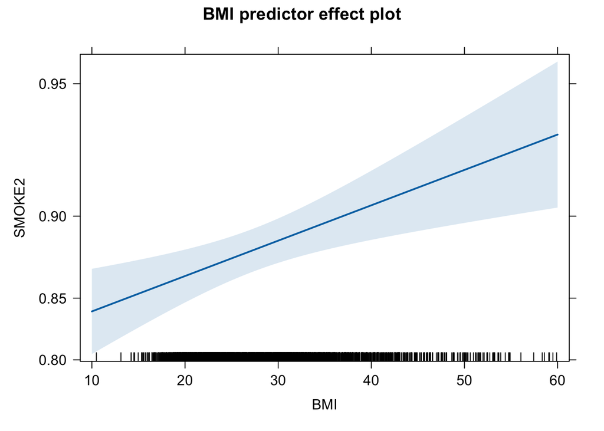

```r
plot(predictorEffect("BMI", smoke.mod2))
```

### Going forward

For your assignment:

1. Pick a few variables you believe might explain BMI at level-1.
2. Try to find a good fitting level 1 model
- Note, that random slopes might lead to singular fits. So it’s ok if your models only have random intercepts
3. Add in the Two-County Predictor at level-2
4. Write up the results and interpretations